# Causal Inference - SWIGs

Michael Knaus

SoSe 25

These are the goals of today:

- Implement SWIGs using `dagitty`
- Generate a causal data generating process

# Getting started

The nice infrastructure `dagitty` and `ggdag` can also be applied to SWIGs.

```
if (!require("dagitty")) install.packages("dagitty", dependencies = TRUE); library(dagitty)
if (!require("ggdag")) install.packages("ggdag", dependencies = TRUE); library(ggdag)
if (!require("tidyverse")) install.packages("tidyverse", dependencies = TRUE); library(tidyverse)
if (!require("patchwork")) install.packages("patchwork", dependencies = TRUE); library(patchwork)
```

# Revisiting RCT

Let’s check what we derived in class

## The DAG

First, this is the DAG in an RCT:

```
rct_dag = dagitty('dag{
                      W [pos = "0,0"]
                      Y [pos = "1,0"]
                      W -> Y
                      }')
ggdag(rct_dag) + theme_dag()
```

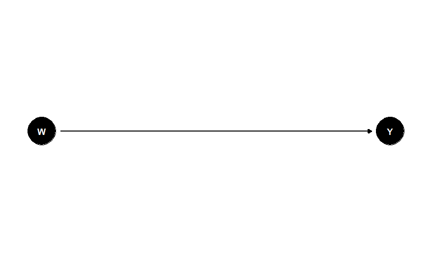

Are there independencies implied?

```
impliedConditionalIndependencies(rct_dag)
```

Of course not. Note that the command outputs just nothing, not even a `character(0)` or something, so don’t get confused.

## The RCT SWIG

```
rct_swig = dagitty('dag{
                      W [pos = "0,0"]
                      w [pos = "0.2,0"]
                      Yw [pos = "1,0"]
                      w -> Yw
                      }')
ggdag(rct_swig) + theme_dag()
```

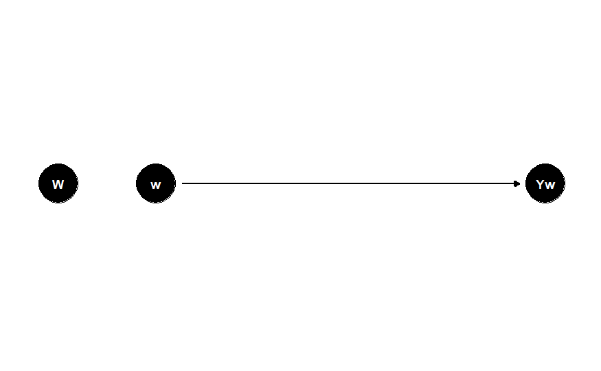

Are there independencies implied?

```
impliedConditionalIndependencies(rct_swig)
```

```
W _||_ Yw
W _||_ w
```

Yes, the familiar independence between randomly assigned treatment and PO. Note that we can ignore the second independence. Any independence with `w` holds trivially because any variable is independent of a constant.

To see this note, e.g. that $Cov(W,w) = 0 = E[Ww] - E[W] E[w] = E[W] w - E[W] w = 0$ b/c $w$ is a constant.

## (optional self-study) Implement the SWIGs of slides 10 to 12

Check implied independencies between the random part of the variable(s) intervened on and the potential outcomes.

# Simple confounding

Draw the DAG:

```
sc_dag = dagitty('dag{
                      W [pos = "0,0"]
                      Y [pos = "1,0"]
                      X [pos = "0.5,1"]
                      W -> Y
                      X -> W
                      X -> Y
                      }')
ggdag(sc_dag) + theme_dag()
```

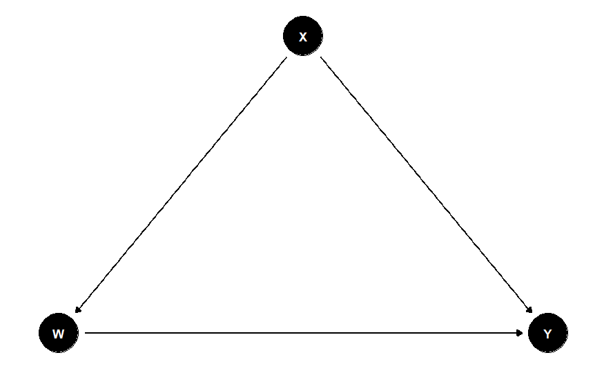

Are there independencies implied?

```
impliedConditionalIndependencies(sc_dag)
```

Nope.

Create the SWIG:

```
sc_swig = dagitty('dag{
                      W [pos = "0,0"]
                      w [pos = "0.2,0"]
                      Yw [pos = "1,0"]
                      X [pos = "0.5,1"]
                      w -> Yw
                      X -> W
                      X -> Yw
                      }')
ggdag(sc_swig) + theme_dag()
```

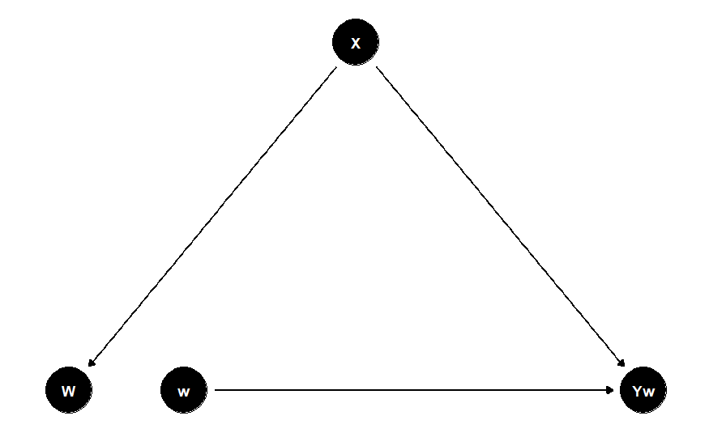

and find the canonical independence $Y(w) \perp\mkern-10mu\perp W \mid X$:

```
impliedConditionalIndependencies(sc_swig)
```

```
W _||_ Yw | X
W _||_ w
X _||_ w
```

# SWIG in a more complex graphs

Revisit a graph similar to the previous exercise:

```
G = dagitty('dag{     A [pos = "0,1"]
                      B [pos = "1,1"]
                      C [pos = "2,1"]
                      D [pos = "0,-1"]
                      W [pos = "0,0"]
                      M [pos = "1,-1"]
                      Y [pos = "2,0"]
                      B -> W
                      B -> C
                      A -> W
                      C -> W
                      C -> Y
                      W -> M
                      W -> D
                      W -> Y
                      M -> Y}')

ggdag(G) + theme_dag()
```

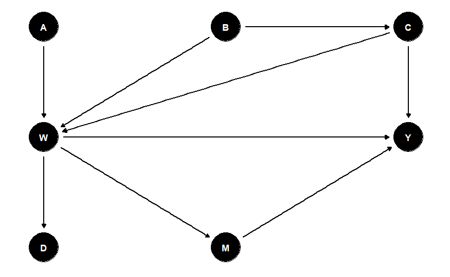

Create the SWIG for intervening on $W$ by

1. Splitting the treatment node and
2. Relabel the descendants of $w$

```
SWIG = dagitty('dag{ B [pos = "1,1"]
                      A [pos = "0,1"]
                      C [pos = "2,1"]
                      W [pos = "0,0"]
                      w [pos = "0.3,0"]
                      Mw [pos = "1,-1"]
                      Yw [pos = "2,0"]
                      Dw [pos = "0,-1"]
                      B -> W
                      B -> C
                      A -> W
                      C -> W
                      C -> Yw
                      w -> Mw
                      w -> Dw
                      w -> Yw
                      Mw -> Yw}')

ggdag(SWIG) + theme_dag()
```

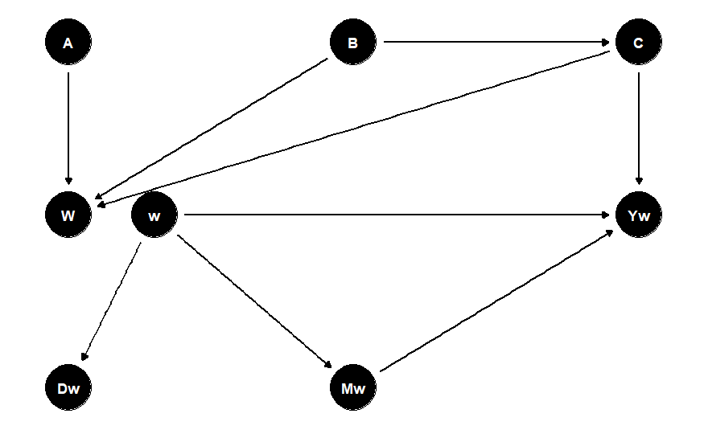

Check the independencies contained in the SWIG:

```
# impliedConditionalIndependencies(SWIG,type="all")
```

These are too many and nearly all of them are irrelevant.

Let’s write a function `ci_filter(impliedConditionalIndependencies,treatment,PO)` that takes a impliedConditionalIndependencies object, the treatment label and the PO label as input and only prints independencies involving treatment $\perp\mkern-10mu\perp$ PO or PO $\perp\mkern-10mu\perp$ treatment.

```
ci_filter = function(iCI, treatment, PO) {
  filtered_list = vector("list", length(iCI))
  for (i in seq_along(iCI)) {
    if (
      ((iCI[[i]][["X"]] == treatment) & (iCI[[i]][["Y"]] == PO) | (iCI[[i]][["X"]] == PO) & (iCI[[i]][["Y"]] == treatment)) & !any(grepl("w$", iCI[[i]][["Z"]]))
      ) {
      filtered_list[[i]] = iCI[[i]]
    }
  }
  filtered_list = filtered_list[!sapply(filtered_list, is.null)]
  return(filtered_list)
}

CI_SWIG = ci_filter(impliedConditionalIndependencies(SWIG,type="all"), "W", "Yw")
CI_SWIG
```

```
[[1]]
W _||_ Yw | C

[[2]]
W _||_ Yw | A, C

[[3]]
W _||_ Yw | B, C

[[4]]
W _||_ Yw | A, B, C
```

What are valid adjustment sets according to the counterfactual adjustment criterion?

$$X =
\{C\},\{A,C\},\{B,C\},\{A,B,C\}$$

Which valid adjustment set is missing and can therefore not be found using the counterfactual adjustment criterion?

D

# Simulate a data generating process

Define and program a data generating process with

- One continuous confounding variable $X$
- A binary treatment $W$
- A continuous outcome $Y$

## Define data generating process

Define a toy parametric model:

- $X := f_X(U_X) = uniform(-1,1)$
- $W := f_W(X,U_W) = 1[\alpha_0 + \alpha_1 X + U_W > 0]$ with $U_W \sim logistic(0,1)$
- $Y := f_Y(W,X,U_Y) = \beta_0 + \beta_1 X + \beta_2 W + \beta_3 W X + U_Y$ with $U_Y \sim \mathcal{N}(0,1)$

Write down the explicit form of

1. potential outcomes under control $Y(0) = f_Y(0,X,U_Y) = \beta_0 + \beta_1 X + U_Y$
2. potential outcomes under treatment $Y(1) = f_Y(1,X,U_Y) = \beta_0 + \beta_1 X + \beta_2 + \beta_3 X + U_Y$
3. $\gamma_0(X) := E[Y(0)|X] = E[\beta_0 + \beta_1 X + U_Y|X] = \beta_0 + \beta_1 X + \underbrace{E[U_Y|X]}_{=0} = \beta_0 + \beta_1 X$
4. $\gamma_1(X) := E[Y(1)|X] = \beta_0 + \beta_1 X + \beta_2 + \beta_3 X$
5. ITE $Y(1) - Y(0) = \beta_2 + \beta_3 X$
6. CATE $\tau(X) := E[Y(1) - Y(0)|X] = \beta_2 + \beta_3 X$
7. ATE $E[Y(1) - Y(0)] = \beta_2 + \beta_3 \underbrace{E[X]}_{=0} = \beta_2$
8. The treatment probability $e(X) := P(W = 1 | X) = \frac{e^{\alpha_0 + \alpha_1 X}}{1 + e^{\alpha_0 + \alpha_1 X}}$

Assume that
$$\alpha_0 = \alpha_1 =
\beta_0 = \beta_1 = \beta_2 = 0$$
and that
$$\beta_3 = 1$$

Which setting is resembled by this?

Let’s plot the DGP

```
alpha0 = 0
alpha1 = 0
beta0 = 0
beta1 = 0
beta2 = 0
beta3 = 1
e = function(x){exp(alpha0 + alpha1 * x) / (1 + exp(alpha0 + alpha1 * x))}
m0 = function(x){beta0 + beta1 * x}
m1 = function(x){beta0 + beta1 * x + beta2 + beta3 * x}
tau = function(x){m1(x) - m0(x)}

g1 = data.frame(x = c(-1, 1)) %>% ggplot(aes(x)) + stat_function(fun=e,linewidth=1) + ylab("e(x)") + xlab("X1")
g2 = data.frame(x = c(-1, 1)) %>% ggplot(aes(x)) + stat_function(fun=m1,linewidth=1,aes(colour="gamma1")) +
  stat_function(fun=m0,linewidth=1,aes(colour="gamma0")) + ylab("gamma(x)") + xlab("X1")
g3 = data.frame(x = c(-1, 1)) %>% ggplot(aes(x)) + stat_function(fun=tau,linewidth=1) + ylab(expression(tau(x))) + xlab("X1")
g1 / g2 / g3
```

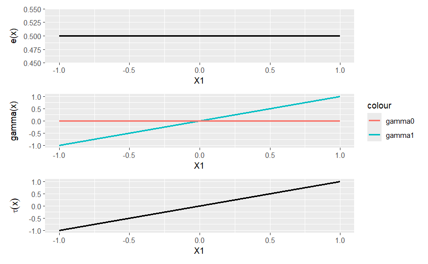

# Draw sample

Finally simulate a dataset with $n=100000$ from this data generating process:

- Define the parameters

```
n = 100000
```

- Draw $X$:

```
X = runif(n,-1,1)
hist(X)
```

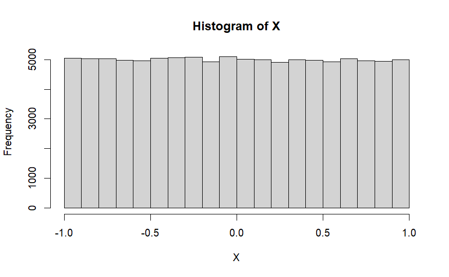

- Generate $W$:

```
UW = rlogis(n)
# hist(UW)
W = (alpha0 + alpha1 * X + UW > 0) * 1
table(W)
```

```
W
    0     1
49979 50021
```

- Generate $Y$:

```
UY = rnorm(n)
Y = beta0 + beta1 * X + beta2 * W + beta3 * X * W + UY
hist(Y)
```

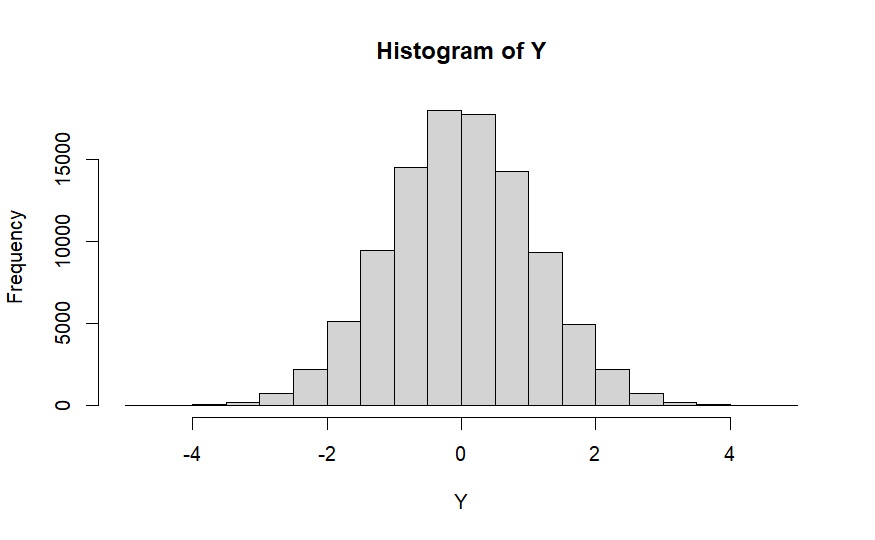

```
hist(X[W==0])
```

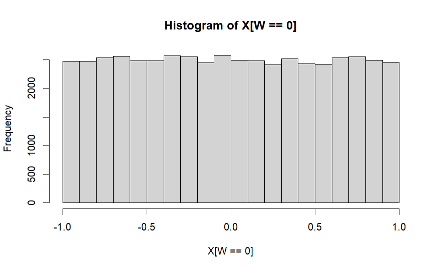

```
hist(X[W==1])
```

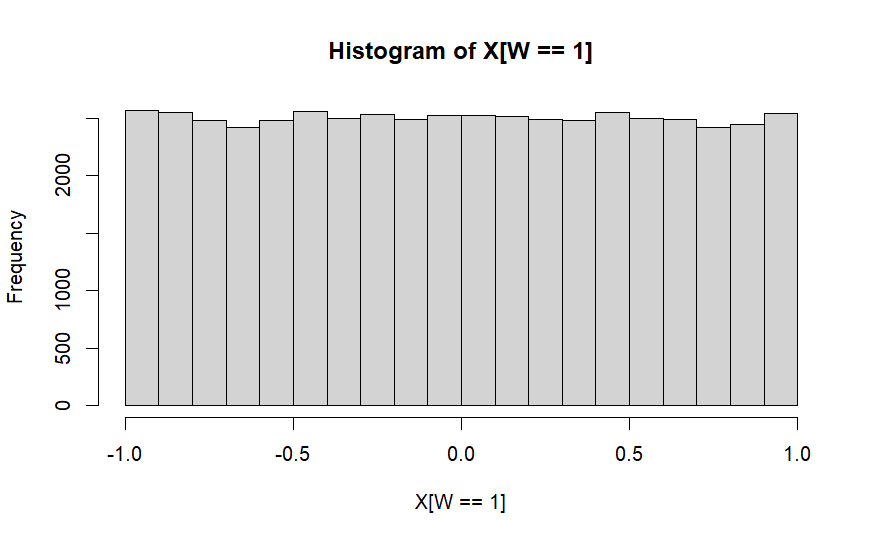

Explicitly calculate and plot the two potential outcomes:

```
Y0 = beta0 + beta1 * X + UY
Y1 = beta0 + beta1 * X + beta2  + beta3 * X + UY

# Combine the data into a data frame for ggplot
data <- data.frame(
  value = c(Y0, Y1),
  group = factor(rep(c("Y0", "Y1"), each = length(Y0)))
)

# Create the overlapping histograms
ggplot(data, aes(x = value, fill = group)) +
  geom_histogram(alpha = 0.5, position = "identity", bins = 30) +
  labs(title = "Overlapping Histograms of Y0 and Y1",
       x = "Value",
       y = "Count") +
  theme_minimal() +
  scale_fill_manual(values = c("blue", "red"))
```

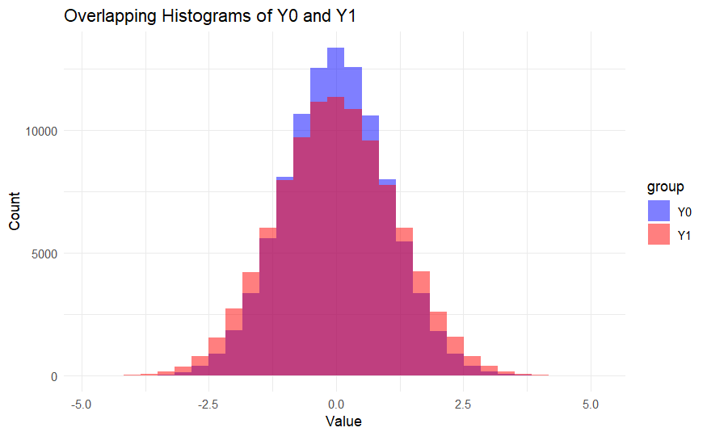

Calculate the ITE and plot its distribution:

```
ite = Y1 - Y0
hist(ite)
```

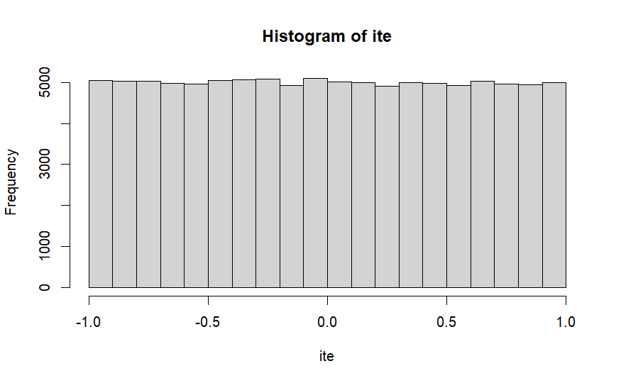

Explicitly calculate the sample ATE:

```
ite = Y1 - Y0
hist(ite)
```

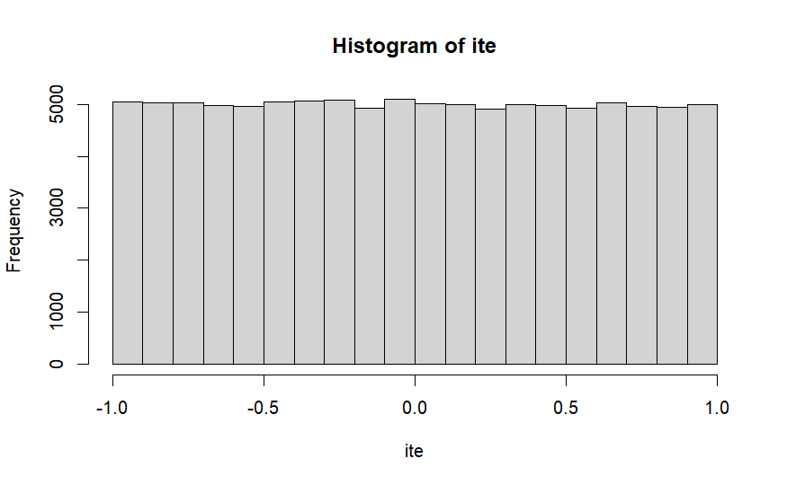

```
sate = mean(ite)
sprintf("The SATE is %.4f", sate)
```

```
[1] "The SATE is -0.0025"
```

```
sprintf("SATE - ATE is %.4f", sate - beta2)
```

```
[1] "SATE - ATE is -0.0025"
```

## Estimation

Finally, estimate the ATE using a mean comparison:

```
atehat = mean(Y[W==1]) - mean(Y[W==0])
sprintf("The estimated ATE is %.4f", atehat)
```

```
[1] "The estimated ATE is 0.0084"
```